# Quantitative Genomics and Genetics 2016

## Computer Lab 10

– 28 April 2016

– Author: Jin Hyun Ju (jj328@cornell.edu)

### EM algorithm

I am including a mini exercise about the EM algorithm for those of you who are interested. In class we learned about mixed models and the EM algorithm to estimate the parameter values for the mixed model. The process of the EM algorithm is outlined below. Basically, what happens is that it fixes the parameters (betas, and sigmas) for the first step to calculate the best estimate for a and Va and in the next step it uses the values calculated for a and Va to update the betas and the sigmas until the values don’t change much (reach convergence).

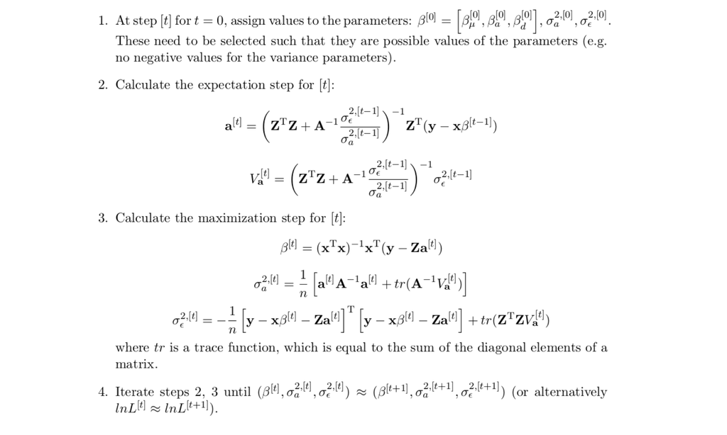

The actual R code to run an EM algorithm on the dataset that is posted on the website (QG14_Lab11_EM_files.tar.gz) is shown below. Here are some mini tasks regarding this exercise:

- Take a look at the given data and inspect the dimensions of each.
- For the given code, include a line that prints out the log likelihood for each iteration (Ex. iteration = 1, loglikelihood = 500.123). Also plot the log likelihood for each iteration in a line. What does it look like?
- Compare the results of the EM algorithm to the results of a simple linear fixed effect model and see what is different.

```r
X = as.matrix(read.table("QG16_Lab11_EM_X.txt"))
Y = as.matrix(read.table("QG16_Lab11_EM_Y.txt"))
A = as.matrix(read.table("QG16_Lab11_EM_A.txt"))



EM_algorithm = function(Y, X_j, A){


  # Calculate the inverse of A once since it is used repeatedly in the algorithm
    # This method is faster than solve(A)
    solve_A = chol2inv(chol(A))

    n = length(Y)

    I = diag(1, n)

    log_L = c()
    # set starting values
    sigma_sq_a = 70
    sigma_sq_e = 10
    beta = as.vector(rep(0, ncol(X_j)))


    C = A * sigma_sq_a + I * sigma_sq_e
    log_L[1] = -1/2 * determinant(C)$modulus - 1/2 * t(Y - X_j %*% beta) %*% chol2inv(chol(C)) %*% (Y - X_j %*% beta)
    iter = 2

    while(1){

        S = chol2inv(chol(I + solve_A * sigma_sq_e / sigma_sq_a))

        alpha = S %*% (Y - X_j %*% beta)

        V = S  * sigma_sq_e

        beta = chol2inv(chol(t(X_j) %*% X_j)) %*% t(X_j) %*% (Y - alpha)

        # use as.numeric() to make sure value is saved as a scalar
        sigma_sq_a = as.numeric(1/n * (t(alpha) %*% solve_A %*% alpha + sum(diag(solve_A %*% V))))

        # use as.numeric() to make sure value is saved as a scalar
        sigma_sq_e = as.numeric( 1/n * ( t(Y - X_j %*% beta - alpha) %*% (Y - X_j %*% beta - alpha) + sum(diag(V))))

        C = A * sigma_sq_a + I * sigma_sq_e
        log_L[iter] = -1/2 * determinant(C)$modulus - 1/2 * t(Y - X_j %*% beta) %*% chol2inv(chol(C)) %*% (Y - X_j %*% beta)

        if(log_L[iter] - log_L[iter-1] < 1e-5){
            break;
        }

        iter = iter + 1
    }

    return(list(beta = beta,
            sigma_sq_a = sigma_sq_a,
            sigma_sq_e = sigma_sq_e,
            log_L = log_L[iter-1]))

}



###############
# Mixed model #
###############

n_indivs = length(Y)

# Null model
One = as.matrix(rep(1, n_indivs))
log_L_null = EM_algorithm(Y, One, A)$log_L

p_values_EM = c()

# Full model
for(j in 1:ncol(X)){

        X_j = cbind(1, X[,j])

        fit = EM_algorithm(Y, X_j, A)

        p_values_EM[j] = pchisq(-2 * (log_L_null - fit$log_L), 1, lower.tail=FALSE)

    cat('.')
}
```